# 2023 EPA Openscapes Champions Cohort

Welcome to the 2023 EPA Openscapes Champions Cohort! This is a Cohort for the U.S Environmental Protection Agency, Center for Environmental Measurement and Modeling (CEMM). Learn more about [Openscapes](https://openscapes.org/) and the [EPA CEMM](https://www.epa.gov/aboutepa/about-center-environmental-measurement-and-modeling-cemm). Happy to be here!

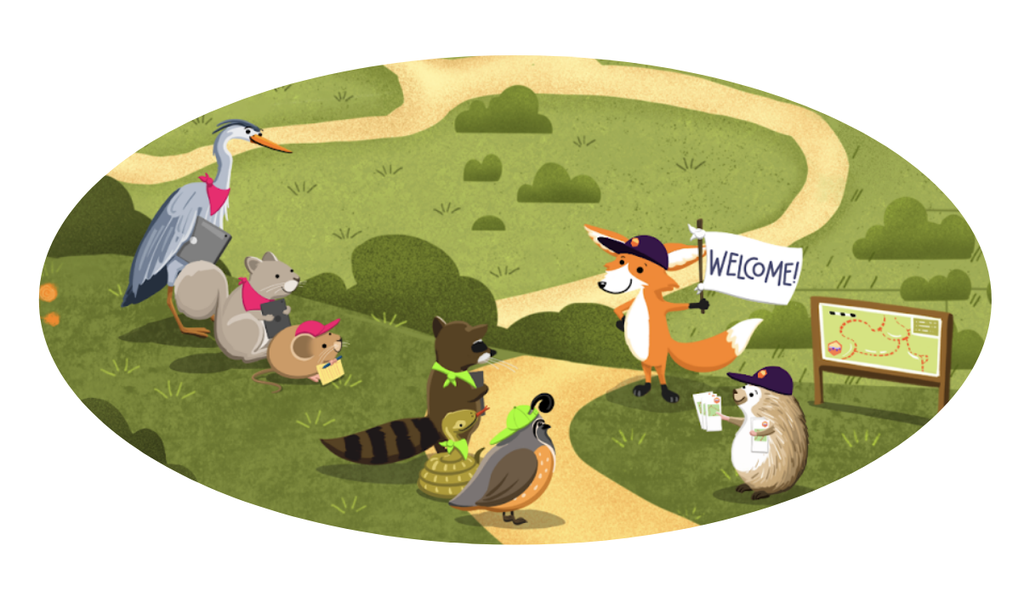

## Cohort Agendas

We will meet as a Cohort via MS Teams six times over two months for 1.5 hours on Wednesdays starting February 15, 2023:

- **Dates: February 15, March 1, 15, 29, April 12, 26**
- **Times: 10:00 - 11:30am PT / 1:00 - 2:30 pm ET**
- **Location: Remotely, via MS Teams**

Agendas are accessible to Cohort participants in our Cohort Sharepoint Folder; they are also an archive of our live notetaking. Please see https://openscapes.org/series to view blank versions of the agendas.

| Date | Cohort Call Topics | Series Chapters | Seaside Chat Topics |
| --- | --- | --- | --- |
| 02/15 | 1. Openscapes mindset | mindset, [better science in less time](https://openscapes.github.io/series/better-science.html) | Reflect together on what you’ve learned |
| 03/01 | 2. Pathways introduction; documentation | [pathways](https://openscapes.github.io/series/core-lessons/pathways.html) | Pathway trailhead; create GitHub accounts |
| 03/15 | 3. GitHub Clinic: publishing and project management | [publishing](https://openscapes.github.io/series/github-pub), [project management](https://openscapes.github.io/series/github-issues) | Shared organizing with GitHub |
| 03/29 | 4. Team culture and data strategies for future us | [team culture](https://openscapes.github.io/series/team-culture), [data strategies](https://openscapes.github.io/series/data-strategies) | Onboarding documentation |
| 04/12 | 5. Open communities and coding strategies for future us | [coding with communities](https://openscapes.github.io/series/communities), [coding strategies](https://openscapes.github.io/series/coding-strategies) | Pathways preparation |
| 04/26 | 6. Pathways share |  |  |

**Cohort Call Digests** are posted as issues in this repo.

## Coworking times (optional)

Coworking with Julie, Stefanie, Gayle, and Jeff, for 1 hour in the weeks between Cohort Calls - day and times tbd.

## Participating teams

Upcoming: These are the teams participating: please add any edits directly (we’ll learn how in our GitHub Call!) Take some inspiration from here: https://github.com/Openscapes/2021-noaa-nmfs/blob/main/README.md

Add: - What kind of team you are (cross-divisional) or where you are from (division focusing on…) - Links to your program and what you are working on together - Descriptions of your potential projects. Feel free to list them out [1), 2), 3),…] or provide a longer description. - Who is on your team

**The LIS Hypoxia Prediction Team** is a team composed of [EPA CEMM](https://www.epa.gov/aboutepa/about-center-environmental-measurement-and-modeling-cemm) and [Long Island Sound Study](https://longislandsoundstudy.net/) members, including two ORISE fellows. This team’s focus will be on creating a model specific to the Long Island Sound for predicting hypoxia from prior years of data and other relevant parameters. We will make every attempt to incorporate Open Science principles into our work by 1) Clearly indicating all data inputs used and how they are processed, 2) Building the model in (currently) private a github repository (LIS.Hypoxia.Forecast) and tracking its progress therein, allowing all team members to contribute ideas and tweaks to improve accuracy, 3) Ultimately automating the data inflows to the model as much as possible using public facing apis from monitoring organizations, and 4) Publicizing the model with a straightforward explanation and visuals to aid in understanding its prediction mechanism.

**The Streams Team** is a team composed of EPA scientists in the [Office of Research and Development](https://www.epa.gov/aboutepa/about-office-research-and-development-ord) and Virginia Department of Environmental Quality scientists in [VDEQ’s probabilistic monitoring program](https://www.deq.virginia.gov/water/water-quality/monitoring/probabilistic-monitoring).

## Openscapes team

**Julie Lowndes** (@jules32), Openscapes

**Stefanie Butland** (@stefaniebutland), Openscapes

**Gayle Hagler**, EPA

**Jeff Hollister** (@jhollist), EPA

**Farnaz Nojavan** (@farnazn), EPA